## Background

Using devices such as Jawbone Up, Nike FuelBand, and Fitbit it is now possible to collect a large amount of data about personal activity relatively inexpensively. These type of devices are part of the quantified self movement – a group of enthusiasts who take measurements about themselves regularly to improve their health, to find patterns in their behavior, or because they are tech geeks. One thing that people regularly do is quantify how much of a particular activity they do, but they rarely quantify how well they do it. In this project, your goal will be to use data from accelerometers on the belt, forearm, arm, and dumbell of 6 participants. They were asked to perform barbell lifts correctly and incorrectly in 5 different ways. More information is available from the website here: http://groupware.les.inf.puc-rio.br/har (see the section on the Weight Lifting Exercise Dataset).

## Data

The training data for this project are available here: https://d396qusza40orc.cloudfront.net/predmachlearn/pml-training.csv The test data are available here: https://d396qusza40orc.cloudfront.net/predmachlearn/pml-testing.csv

## Preparing the environment

The required libraries were loaded. We also set the seed for the environment

```r
library(AppliedPredictiveModeling)

library(caret)
library(rpart)

library(rattle)
library(randomForest)
library(doParallel)
set.seed(12345)
```

## Data Importing

The data was read from the urls and NAs removed while importing

```r
trainurl<-"https://d396qusza40orc.cloudfront.net/predmachlearn/pml-training.csv"

testurl<- "https://d396qusza40orc.cloudfront.net/predmachlearn/pml-testing.csv"



training <- read.csv(trainurl,na.strings = c("NA","#DIV/0!",""))

testing<-read.csv(testurl,na.strings = c("NA","#DIV/0!",""))
```

## Data Cleaning

Removed the missing values NAs from the data

```r
trNAs <-colMeans(is.na(training))

training_noNAs<-training[!trNAs]

dim(training_noNAs)
```

```
## [1] 19622    60
```

The following columns were removed from the predictor list by intuition as these do not contribute towards the outcome variable classe:

X,user_name,raw_timestamp_part_1,raw_timestamp_part_2,cvtd_timestamp,new_window,num_window

```r
training_useful <- training_noNAs[-(1:7)]

dim(training_useful)
```

```
## [1] 19622    53
```

```r
feature_set<-colnames(training_useful)
```

## Data Partioning

For doing cross validation, the data was split into training and testing data with 70% of the data contributing to training

```r
inTrain = createDataPartition(training_useful$classe, p = 0.7,list=FALSE)

train_part = training_useful[ inTrain,]

test_part = training_useful[-inTrain,]

dim(train_part)
```

```
## [1] 13737    53
```

```r
dim(test_part)
```

```
## [1] 5885   53
```

## Decision trees

```r
fitcontrol<-trainControl(method="cv",number = 5)

modFitrpart<-train(classe~.,method="rpart",data=train_part)

modFitrpart
```

```
## CART

##

## 13737 samples

##    52 predictor

##     5 classes: 'A', 'B', 'C', 'D', 'E'

##

## No pre-processing

## Resampling: Bootstrapped (25 reps)

## Summary of sample sizes: 13737, 13737, 13737, 13737, 13737, 13737, ...

## Resampling results across tuning parameters:

##

##   cp          Accuracy   Kappa

##   0.03753433  0.5026505  0.35073171

##   0.05987862  0.4020919  0.18507249

##   0.11585800  0.3269323  0.06479018

##

## Accuracy was used to select the optimal model using  the largest value.

## The final value used for the model was cp = 0.03753433.
```

We can visualize the decision tree by plotting as below

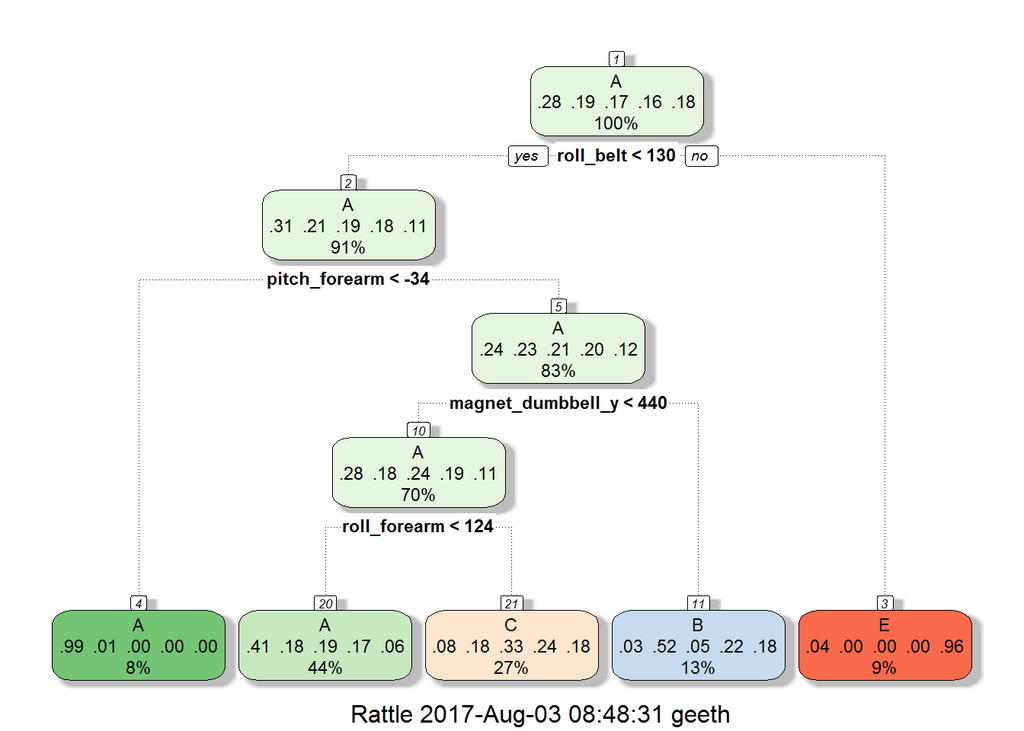

```r
fancyRpartPlot(modFitrpart$finalModel)
```

Predicting this model on the validation data, we get the statistics as follows

```r
predrpart <- predict(modFitrpart, newdata =test_part[,1:52])

confusionMatrix( predrpart,test_part$classe)
```

```
## Confusion Matrix and Statistics

##

##           Reference

## Prediction    A    B    C    D    E

##          A 1494  470  467  438  141

##          B   21  380   29  184  147

##          C  128  289  530  342  277

##          D    0    0    0    0    0

##          E   31    0    0    0  517

##

## Overall Statistics

##

##                Accuracy : 0.4963

##                  95% CI : (0.4835, 0.5092)

##     No Information Rate : 0.2845

##     P-Value [Acc > NIR] : < 2.2e-16

##

##                   Kappa : 0.3425

##  Mcnemar's Test P-Value : NA

##

## Statistics by Class:

##

##                      Class: A Class: B Class: C Class: D Class: E

## Sensitivity            0.8925  0.33363  0.51657   0.0000  0.47782

## Specificity            0.6400  0.91972  0.78679   1.0000  0.99355

## Pos Pred Value         0.4963  0.49934  0.33844      NaN  0.94343

## Neg Pred Value         0.9374  0.85187  0.88516   0.8362  0.89414

## Prevalence             0.2845  0.19354  0.17434   0.1638  0.18386

## Detection Rate         0.2539  0.06457  0.09006   0.0000  0.08785

## Detection Prevalence   0.5115  0.12931  0.26610   0.0000  0.09312

## Balanced Accuracy      0.7662  0.62667  0.65168   0.5000  0.73568
```

From the above we see that the accuracy is very low for predicting on the evaluation data, so this method will not be used

## Random Forest

Now, we try to fit the random forest algorithm to build the model.The number of trees were set as 1000. Parallel processing was used to cut down the execution time. The variable classe was predicted based on the reamaining 52 predictors.

```r
registerDoParallel()

rf<-foreach(ntree=rep(250,4),.combine = randomForest::combine,.packages = "randomForest") %dopar%{

  randomForest(train_part[,-53],train_part$classe,ntree=ntree)

}

rf
```

```
##

## Call:

##  randomForest(x = train_part[, -53], y = train_part$classe, ntree = ntree)

##                Type of random forest: classification

##                      Number of trees: 1000

## No. of variables tried at each split: 7
```

The above model was used on the validation data to predict the known outcome. To check the accuracy of prediction, confusionmatrix was obtained

```r
predrf <- predict(rf, newdata =test_part[,1:52])

confusionMatrix(predrf, test_part$classe)
```

```
## Confusion Matrix and Statistics

##

##           Reference

## Prediction    A    B    C    D    E

##          A 1673   11    0    0    0

##          B    1 1125   10    0    0

##          C    0    3 1016   13    0

##          D    0    0    0  951    5

##          E    0    0    0    0 1077

##

## Overall Statistics

##

##                Accuracy : 0.9927

##                  95% CI : (0.9902, 0.9947)

##     No Information Rate : 0.2845

##     P-Value [Acc > NIR] : < 2.2e-16

##

##                   Kappa : 0.9908

##  Mcnemar's Test P-Value : NA

##

## Statistics by Class:

##

##                      Class: A Class: B Class: C Class: D Class: E

## Sensitivity            0.9994   0.9877   0.9903   0.9865   0.9954

## Specificity            0.9974   0.9977   0.9967   0.9990   1.0000

## Pos Pred Value         0.9935   0.9903   0.9845   0.9948   1.0000

## Neg Pred Value         0.9998   0.9971   0.9979   0.9974   0.9990

## Prevalence             0.2845   0.1935   0.1743   0.1638   0.1839

## Detection Rate         0.2843   0.1912   0.1726   0.1616   0.1830

## Detection Prevalence   0.2862   0.1930   0.1754   0.1624   0.1830

## Balanced Accuracy      0.9984   0.9927   0.9935   0.9927   0.9977
```

We see from the above result that the accuracy is very high. So this method will be used on the evaluation data

## Variable Importance

From the above prediction model, we can see the 20 most important variables in their order of importance

```r
varimp<-varImp(rf)

vars<-rownames(varimp)[order(varimp$Overall, decreasing=TRUE)]

vars[1:20]
```

```
##  [1] "roll_belt"         "yaw_belt"          "pitch_forearm"

##  [4] "magnet_dumbbell_z" "pitch_belt"        "magnet_dumbbell_y"

##  [7] "roll_forearm"      "magnet_dumbbell_x" "roll_dumbbell"

## [10] "accel_dumbbell_y"  "accel_belt_z"      "magnet_belt_z"

## [13] "magnet_belt_y"     "accel_dumbbell_z"  "accel_forearm_x"

## [16] "roll_arm"          "gyros_belt_z"      "magnet_forearm_z"

## [19] "magnet_arm_x"      "yaw_dumbbell"
```

## Visualize the variable importance

We can see the most important variables and their strengths from the following plot

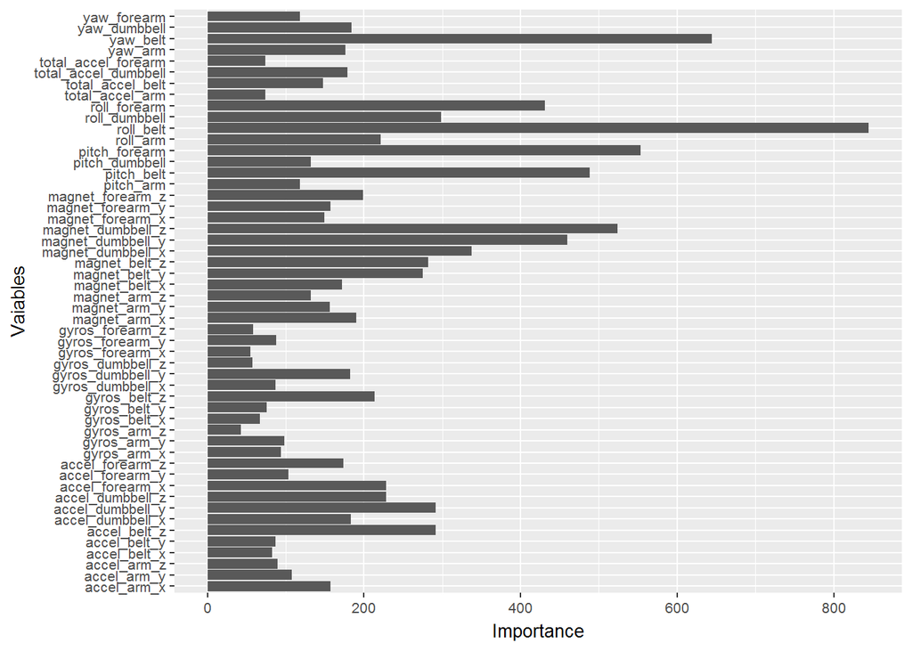

```r
qplot(rownames(varimp),varimp$Overall,

      geom=c("col"))+coord_flip()+theme(text = element_text(size=10))+

  xlab("Vaiables")+ylab("Importance")
```

## Prediction on the out of sample data

We applied the prediction model on the evaluation data. We got 100 % accuracy on the prediction quiz

```r
testing_useful<-testing[feature_set[-53]]

predict(rf,newdata = testing_useful)
```

```
##  1  2  3  4  5  6  7  8  9 10 11 12 13 14 15 16 17 18 19 20

##  B  A  B  A  A  E  D  B  A  A  B  C  B  A  E  E  A  B  B  B

## Levels: A B C D E
```